# Iris Flower Analysis

Kamara Rowe-Ciftci (Meryem)

2025-01-01

## Introduction

**This document is a practice of my R programming skills**, where I have created my first R Markdown file. In this analysis, I explore the built-in Iris data set in R, focusing on the petal and sepal characteristics—specifically their length and width across different Iris species.

By the end of this document, I hope you find the analysis informative and gain insights into these characteristics, as well as develop an understanding of how they differentiate among the Iris species.

### Iris flower image with the R code

The sepal is a part of a flower that is typically green and leaf-like. It forms the outter layer of the flower and protects the buds as they develop before it opens. The petal, on the other hand, is the colorful part of the flower pollinators such as bees, birds, butterflies et cetera.

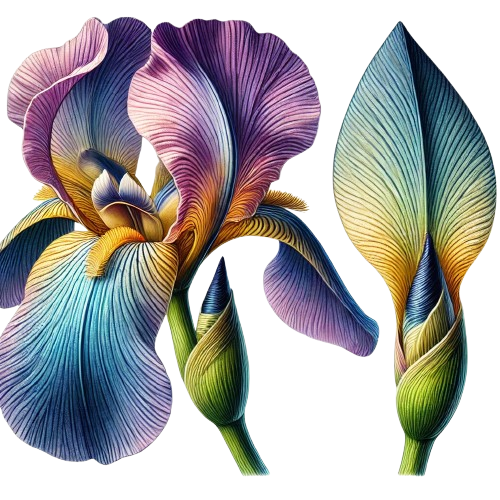

```r
# adding the external image of the Iris flower to the markdown
knitr::include_graphics("iris_flower_sample.png")
```

### Iris Table Summary with the R Code

```r
#Loading the libraries needed to run the date

library(knitr)
library(dplyr)
library(flextable)

#converting summary table to data frame
data("iris")
summary_table <- summary(iris) %>%
  as.matrix() %>%
  as.data.frame()

#adding a column for the lables (min, max, etc)
summary_table <- tibble::rownames_to_column(summary_table, var = "Statistic")

#create the Flextable
flex_table <- flextable(summary_table)

#Add style to the table
flex_table <- flex_table %>%
  set_header_labels(values = list(Statistic = "Summary Statistic")) %>%
  autofit()

#print the table
flex_table
```

| Summary Statistic | Var1 | Var2 | Freq |
| --- | --- | --- | --- |
| 1 |  | Sepal.Length | Min. :4.300 |
| 2 |  | Sepal.Length | 1st Qu.:5.100 |
| 3 |  | Sepal.Length | Median :5.800 |
| 4 |  | Sepal.Length | Mean :5.843 |
| 5 |  | Sepal.Length | 3rd Qu.:6.400 |
| 6 |  | Sepal.Length | Max. :7.900 |
| 7 |  | Sepal.Width | Min. :2.000 |
| 8 |  | Sepal.Width | 1st Qu.:2.800 |
| 9 |  | Sepal.Width | Median :3.000 |
| 10 |  | Sepal.Width | Mean :3.057 |
| 11 |  | Sepal.Width | 3rd Qu.:3.300 |
| 12 |  | Sepal.Width | Max. :4.400 |
| 13 |  | Petal.Length | Min. :1.000 |
| 14 |  | Petal.Length | 1st Qu.:1.600 |
| 15 |  | Petal.Length | Median :4.350 |
| 16 |  | Petal.Length | Mean :3.758 |
| 17 |  | Petal.Length | 3rd Qu.:5.100 |
| 18 |  | Petal.Length | Max. :6.900 |
| 19 |  | Petal.Width | Min. :0.100 |
| 20 |  | Petal.Width | 1st Qu.:0.300 |
| 21 |  | Petal.Width | Median :1.300 |
| 22 |  | Petal.Width | Mean :1.199 |
| 23 |  | Petal.Width | 3rd Qu.:1.800 |
| 24 |  | Petal.Width | Max. :2.500 |
| 25 |  | Species | setosa :50 |
| 26 |  | Species | versicolor:50 |
| 27 |  | Species | virginica :50 |
| 28 |  | Species |  |
| 29 |  | Species |  |
| 30 |  | Species |  |

The table provides a statistical summary of the Iris Plant dataset such as the minimum, maximum, mean, median and 1st and 3rd Quartiles for each sepal and petal measurement.

## **Visualizing the Data**

### Scatter Plot of Sepal Length vs Sepal Width

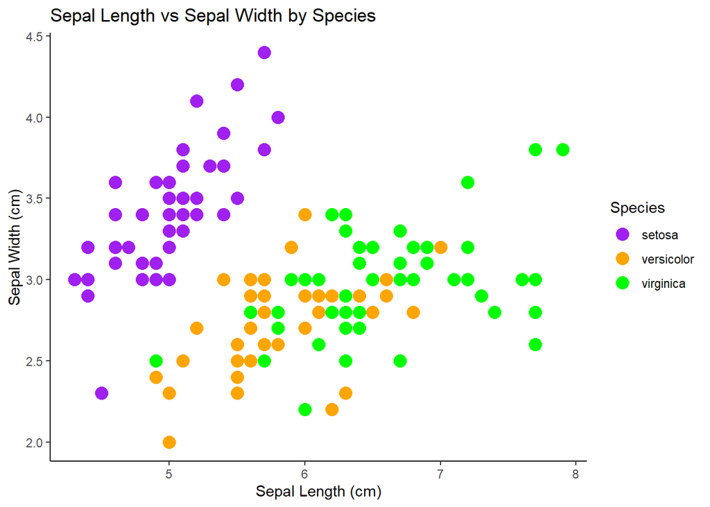

```r
library(ggplot2)

#Custom color palette

custom_colors <- c("setosa" = "purple", "versicolor" = "orange", "virginica" = "green")
my_plot <- ggplot(iris, aes(x = Sepal.Length, y = Sepal.Width, color = Species))+
  geom_point(size = 4) +
  labs(title = "Sepal Length vs Sepal Width by Species",
       x= "Sepal Length (cm)",
       y= "Sepal Width (cm)") +
  scale_color_manual(values = custom_colors) +
theme(panel.grid.major = element_blank(), panel.grid.minor = element_blank(),
      panel.background = element_blank()) +
        theme_classic()

## View the plot
print(my_plot)
```

#### **Chart Observations**

An observation of the scatter plot shows the Setosa species as a wider sepal width compared to Virginica and versicolor. However, there are some virginica that differ in length and width to versicolor but for the most part they have similar length and width.

### Scatter Plot of Petal Length vs Petal Width

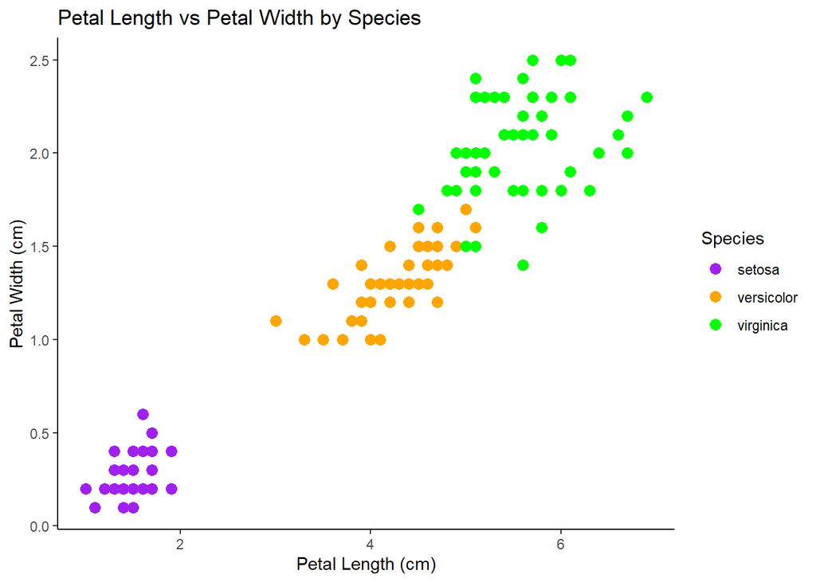

```r
custom_colors <- c("setosa" = "purple", "versicolor" = "orange", "virginica" = "green")

my_plot_2 <-ggplot(iris, aes(x = Petal.Length, y = Petal.Width, color = Species)) +
  geom_point(size = 3) +
  labs(title = "Petal Length vs Petal Width by Species",
       x = "Petal Length (cm)",
       y = "Petal Width (cm)") +
  scale_color_manual(values = custom_colors) +
  theme(panel.grid.major = element_blank(), panel.grid.minor = element_blank(),
      panel.background = element_blank()) +
  theme_classic()

## View the plot
print(my_plot_2)
```

#### **Chart Observations**

Here we observe the comparison of petal length and width. Setosa caught my attention first—it’s clearly separate from the others, sitting close to the bottom of the plot with shorter petals that are also narrower. Setosa is of a smaller side in both length and width.’

What really stood out for me, though, was the contrast in sepal length. While Versicolor and Virginica have similar petal sizes, Virginica’s sepals are clearly longer, making it stand apart from Versicolor, which was more in the middle range.

### Box plot for Sepal Length by Species

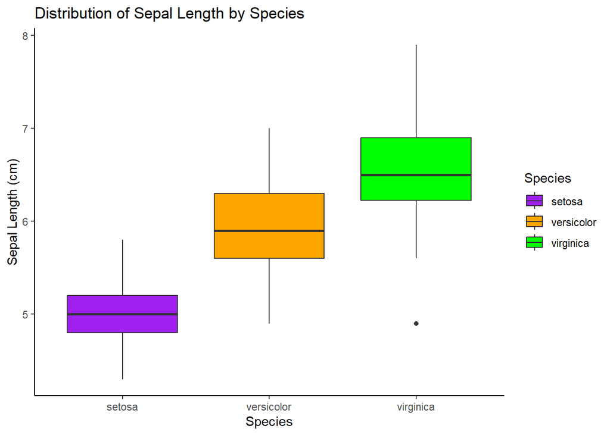

```r
custom_colors <- c("setosa" = "purple", "versicolor" = "orange", "virginica" = "green")

my_plot_3 <- ggplot(iris, aes(x = Species, y = Sepal.Length, fill = Species)) +
  geom_boxplot() +
   labs(title = "Distribution of Sepal Length by Species",
  x = "Species",
  y = "Sepal Length (cm)") +
  scale_fill_manual(values = custom_colors) +
  theme_classic()

## View the plot
print(my_plot_3)
```

#### **Chart Observation**

The box plot pattern observed looks like a step-like pattern. This suggests that Setosa species have the shortest sepals. Versicolor species have an intermediate length sepal and Virginica species have the longest sepals.

**Outliers:** There is one outlier present in the data set for Virginica. This means that there is a data point for the Virginica species that falls outside the expected range. It could be a unique case that represent a very long or very short sepal length in the species. The sepal length could mean longer sepal may offer better protection to the flower buds. Species with smaller sepals may not suggest it does not require protection and grow in environments where there are fewer threats and so the sepal length is standard.

### Box Plot for Petal Length by Species

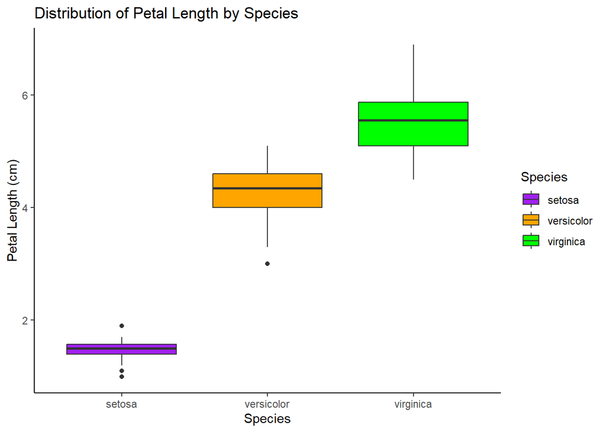

```r
custom_colors <- c("setosa" = "purple", "versicolor" = "orange", "virginica" = "green")
my_plot_4 <- ggplot(iris, aes(x = Species, y = Petal.Length, fill = Species)) +
geom_boxplot() +
labs(title = "Distribution of Petal Length by Species",
x = "Species",
y = "Petal Length (cm)")+
 scale_fill_manual(values = custom_colors)+
theme_classic()

## View the plot
print(my_plot_4)
```

#### **Chart Observations**

Setosa’s narrow box indicates the petal length are tıghtly clustered. The outliers would indicate petal lengths that are significantly different from the rest of the petals. Factors that cause petal length to differ could range from environmental factors to genetics. The low whiskers suggests that the data points are close to the median which means the data points are close together and don’t spread out much. Therefore you could say all the petals look pretty much the same.

Versicolor’s box is wider which means there are differences in the petal length. There is one outlier data point which could mean there is one unusual petal length in the sample. Looking at the spacing with each species. I observe that Versicolor and Virginica boxes are closer together compared to Setosa.It could indicate that these species are similar in petal length. While Setosa’s distance indicates it is distinctly separate in petal length than the other two species.

Virginica does not have an outlier which could indicate that the length and petals are consistent with this species. The longer whiskers could indicate that at the upper part of the species the petals could have a wider lengths.

### Histogram Chart of Sepal Length by Species

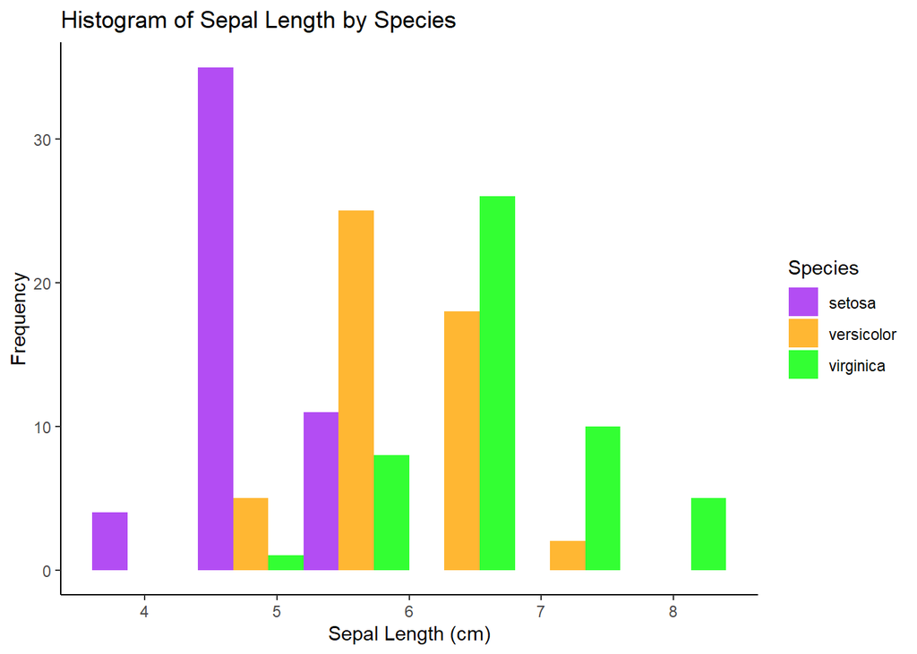

```r
custom_colors <- c("setosa" = "purple", "versicolor" = "orange", "virginica" = "green")
ggplot(iris, aes(x = Sepal.Length, fill = Species)) +
  geom_histogram(binwidth = 0.8, position = "dodge", alpha = 0.8) +
  labs(title = "Histogram of Sepal Length by Species",
       x = "Sepal Length (cm)",
       y = "Frequency") +
  scale_fill_manual(values = custom_colors)+
  theme_classic()
```

#### **Chart Observations**

**Note** Using the “Dodge” in the code makes the histogram charts look more like a column chart or bar chart than a histogram. It was used to separate the bars for the species. Here is a example of what the chart would look like below without the “Dodge” code added.

The isolated Setosa bar suggests that there is an instance or an outlier and this sepal length is distinct from the other species and also for an observation for Virginica. You can also see that the Versicolor and Virginica sepals are similar to each other and more spreadout than Setosa.It can also imply that they overlap in some areas of their data points.

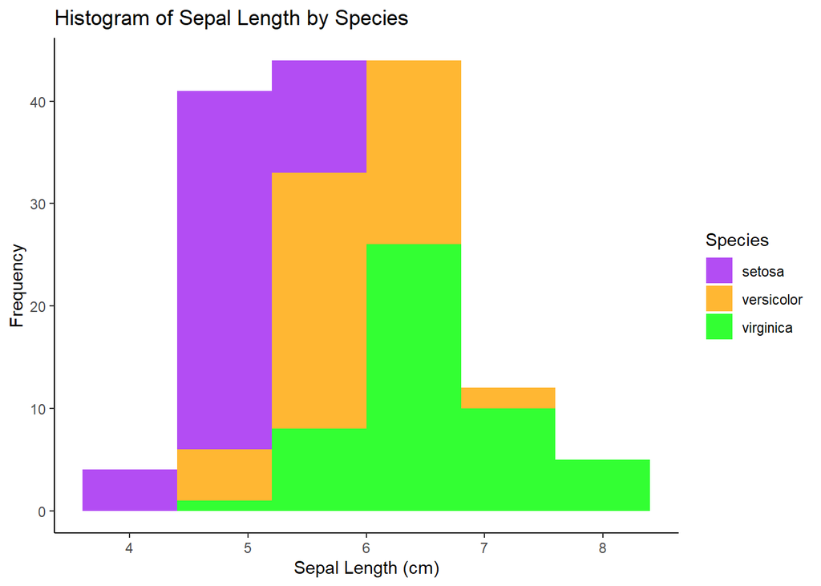

```r
custom_colors <- c("setosa" = "purple", "versicolor" = "orange", "virginica" = "green")
ggplot(iris, aes(x = Sepal.Length, fill = Species)) +
  geom_histogram(binwidth = 0.8, alpha = 0.8) +
  labs(title = "Histogram of Sepal Length by Species",
       x = "Sepal Length (cm)",
       y = "Frequency") +
  scale_fill_manual(values = custom_colors)+
  theme_classic()
```

Example above of a histogram would look like without using the “Dodge” code.

### Sepal Width by Species

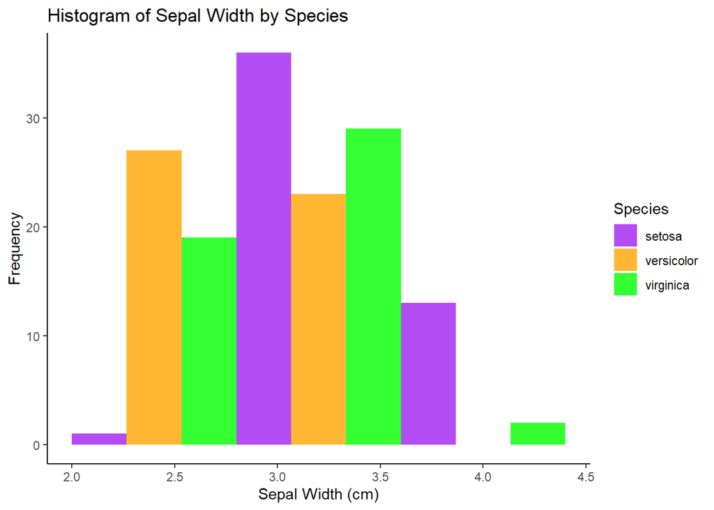

```r
# Histogram for Sepal Width, grouped by Species
custom_colors <- c("setosa" = "purple", "versicolor" = "orange", "virginica" = "green")
ggplot(iris, aes(x = Sepal.Width, fill = Species)) +
  geom_histogram(binwidth = 0.8, position = "dodge", alpha = 0.8) +
  labs(title = "Histogram of Sepal Width by Species",
       x = "Sepal Width (cm)",
       y = "Frequency") +
 scale_fill_manual(values = custom_colors)+
  theme_classic()
```

### Petal Width by Species

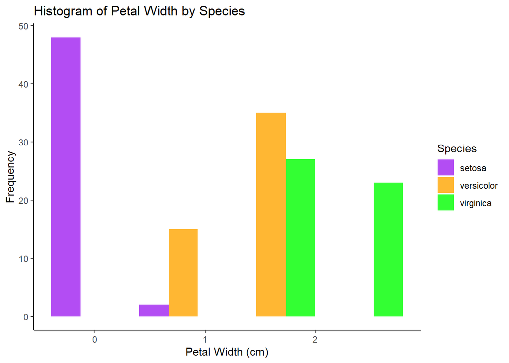

```r
custom_colors <- c("setosa" = "purple", "versicolor" = "orange", "virginica" = "green")
ggplot(iris, aes(x = Petal.Width, fill = Species)) +
  geom_histogram(binwidth = 0.8, position = "dodge", alpha = 0.8) +
  labs(title = "Histogram of Petal Width by Species",
       x = "Petal Width (cm)",
       y = "Frequency") +
  scale_fill_manual(values = custom_colors)+
  theme_classic()
```

#### **Chart Observations**

The Virginica bar standing alone indicates that some Virginica flowers have larger petal widths than any other species. It also indicates the presence of outliers or rare observations.

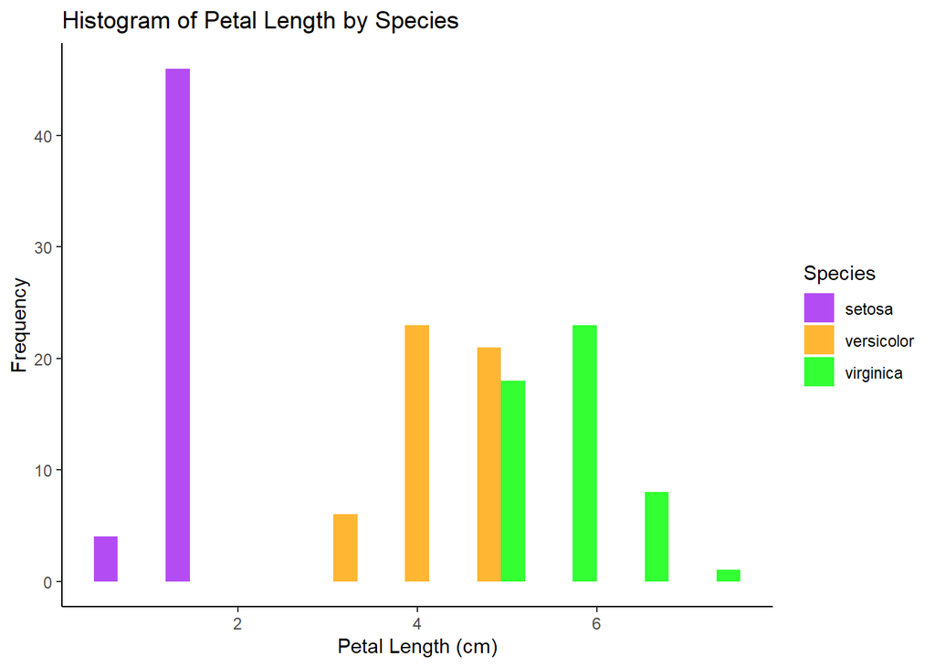

```r
# Histogram for Petal Length, grouped by Species
custom_colors <- c("setosa" = "purple", "versicolor" = "orange", "virginica" = "green")
ggplot(iris, aes(x = Petal.Length, fill = Species)) +
  geom_histogram(binwidth = 0.8, position = "dodge", alpha = 0.8) +
  labs(title = "Histogram of Petal Length by Species",
       x = "Petal Length (cm)",
       y = "Frequency")+
  scale_fill_manual(values = custom_colors)+
  theme_classic()
```

### What I’ve Learned

Working with the Iris data set has deepened my understanding of data visualization and R. I learned how to use `ggplot2` for creating intuitive, customizable plots, and how code like `geom_histogram()` can be tailored with options like `position = "dodge"`. This allowed me to create more informative, clear visualizations that helped in interpreting patterns and distributions.

I also learned about the importance of experimenting with different visual formats and how subtle changes in the code (like adjusting `binwidth` or `alpha`) can significantly affect the readability and insights derived from the data.

Exploring this data set also taught me about understanding data structure and the importance of considering both statistical patterns and visualization aesthetics to communicate insights effectively.

Overall, this project gave me a solid foundation in R and provided valuable practice with interpreting data through the lens of visualization.